# Project: No Show Appointments

- Introduction
- Data Wrangling
- Exploratory Data Analysis
- Conclusions

## Introduction

The medical database contains information about a 100000 patients and focuses on their medical appointments. There is information about the scheduled days for the appointments, the appointment days, their ages, neighbourhoods, health conditions, whether or not they received reminders for their appointments and also whether or not they showed up for their appointment.

Different factors or reasons could have caused the patients to miss their appointments. In this notebook, different factors would be explored as to why patients missed their appointments. Age, sex, whether a patient received a reminder or whether a patient is enrolled in the welfare program would be explored to see if it affects the ability of patients to make it for their appointments.

### Some questions that could be answered through this project are as follows:

```
1. Does the gender of a patient determine whether they show up for an appointment?
2. Does the age of a patient determine whether they show up for an appointment?
3. Does a patient showing up for an appointment depend on receiving an SMS?
4. Does a patient having a scholarship determine whether they show up for an appointment?
5. Does a patient showing up for their appointment depend on how far their neighbourhood is from the hospital?
6. Does a patient showing up for their appointment depend on their health condition?
```

### The following questions will be explored in this analysis:

```
1. Does the gender of a patient determine whether they show up for an appointment?
2. Does the age of a patient determine whether they show up for an appointment?
3. Does a patient showing up for an appointment depend on receiving an SMS?
4. Does a patient having a scholarship determine whether they show up for an appointment?
```

```python
#Packages to be used in this project include Pandas, Numpy and Matplotlib
import pandas as pd
import numpy as np
import matplotlib.pyplot as plt
import seaborn as sns
%matplotlib inline
```

## Data Wrangling

In this section, the data will be loaded and some cleaning will be done. That is, checking for null values, duplicates and handling them, correcting data types and any other process that will make the data easier to work with.

### General Properties

```python
df = pd.read_csv('noshowappointments.csv')
df.head()
```

|  | PatientId | AppointmentID | Gender | ScheduledDay | AppointmentDay | Age | Neighbourhood | Scholarship | Hipertension | Diabetes | Alcoholism | Handcap | SMS_received | No-show |
| --- | --- | --- | --- | --- | --- | --- | --- | --- | --- | --- | --- | --- | --- | --- |
| 0 | 2.987250e+13 | 5642903 | F | 2016-04-29T18:38:08Z | 2016-04-29T00:00:00Z | 62 | JARDIM DA PENHA | 0 | 1 | 0 | 0 | 0 | 0 | No |
| 1 | 5.589978e+14 | 5642503 | M | 2016-04-29T16:08:27Z | 2016-04-29T00:00:00Z | 56 | JARDIM DA PENHA | 0 | 0 | 0 | 0 | 0 | 0 | No |
| 2 | 4.262962e+12 | 5642549 | F | 2016-04-29T16:19:04Z | 2016-04-29T00:00:00Z | 62 | MATA DA PRAIA | 0 | 0 | 0 | 0 | 0 | 0 | No |
| 3 | 8.679512e+11 | 5642828 | F | 2016-04-29T17:29:31Z | 2016-04-29T00:00:00Z | 8 | PONTAL DE CAMBURI | 0 | 0 | 0 | 0 | 0 | 0 | No |
| 4 | 8.841186e+12 | 5642494 | F | 2016-04-29T16:07:23Z | 2016-04-29T00:00:00Z | 56 | JARDIM DA PENHA | 0 | 1 | 1 | 0 | 0 | 0 | No |

### Data Cleaning

```python
df.info()
```

```
<class 'pandas.core.frame.DataFrame'>
RangeIndex: 110527 entries, 0 to 110526
Data columns (total 14 columns):
 #   Column          Non-Null Count   Dtype
---  ------          --------------   -----
 0   PatientId       110527 non-null  float64
 1   AppointmentID   110527 non-null  int64
 2   Gender          110527 non-null  object
 3   ScheduledDay    110527 non-null  object
 4   AppointmentDay  110527 non-null  object
 5   Age             110527 non-null  int64
 6   Neighbourhood   110527 non-null  object
 7   Scholarship     110527 non-null  int64
 8   Hipertension    110527 non-null  int64
 9   Diabetes        110527 non-null  int64
 10  Alcoholism      110527 non-null  int64
 11  Handcap         110527 non-null  int64
 12  SMS_received    110527 non-null  int64
 13  No-show         110527 non-null  object
dtypes: float64(1), int64(8), object(5)
memory usage: 11.8+ MB
```

Information about the dataset is displayed above. This shows the column names, datatypes of each column, and their counts.

```python
df.shape
```

```
(110527, 14)
```

The shape function is used to check the total number of rows and columns in the entire dataset. It can be observed that the dataset has 110527 rows and 14 columns.

```python
df.isnull().sum()
```

```
PatientId         0
AppointmentID     0
Gender            0
ScheduledDay      0
AppointmentDay    0
Age               0
Neighbourhood     0
Scholarship       0
Hipertension      0
Diabetes          0
Alcoholism        0
Handcap           0
SMS_received      0
No-show           0
dtype: int64
```

The code above is used to check if any of the columns have a null value and it can be observed that none of the columns have a null value.

```python
df.describe()
```

|  | PatientId | AppointmentID | Age | Scholarship | Hipertension | Diabetes | Alcoholism | Handcap | SMS_received |
| --- | --- | --- | --- | --- | --- | --- | --- | --- | --- |
| count | 1.105270e+05 | 1.105270e+05 | 110527.000000 | 110527.000000 | 110527.000000 | 110527.000000 | 110527.000000 | 110527.000000 | 110527.000000 |
| mean | 1.474963e+14 | 5.675305e+06 | 37.088874 | 0.098266 | 0.197246 | 0.071865 | 0.030400 | 0.022248 | 0.321026 |
| std | 2.560949e+14 | 7.129575e+04 | 23.110205 | 0.297675 | 0.397921 | 0.258265 | 0.171686 | 0.161543 | 0.466873 |
| min | 3.921784e+04 | 5.030230e+06 | -1.000000 | 0.000000 | 0.000000 | 0.000000 | 0.000000 | 0.000000 | 0.000000 |
| 25% | 4.172614e+12 | 5.640286e+06 | 18.000000 | 0.000000 | 0.000000 | 0.000000 | 0.000000 | 0.000000 | 0.000000 |
| 50% | 3.173184e+13 | 5.680573e+06 | 37.000000 | 0.000000 | 0.000000 | 0.000000 | 0.000000 | 0.000000 | 0.000000 |
| 75% | 9.439172e+13 | 5.725524e+06 | 55.000000 | 0.000000 | 0.000000 | 0.000000 | 0.000000 | 0.000000 | 1.000000 |
| max | 9.999816e+14 | 5.790484e+06 | 115.000000 | 1.000000 | 1.000000 | 1.000000 | 1.000000 | 4.000000 | 1.000000 |

The describe function is used to obtained some summary statistics of the whole dataset, such as the means, standard deviations, the minimum and maximum values which are contained in the dataset. From here, it can be observed that the minimum age is -1 which is highly impossible so that must be corrected.

```python
df['Age'].min()
```

```
-1
```

```python
df['Age'].max()
```

```
115
```

```python
df[df['Age'] == -1]
```

|  | PatientId | AppointmentID | Gender | ScheduledDay | AppointmentDay | Age | Neighbourhood | Scholarship | Hipertension | Diabetes | Alcoholism | Handcap | SMS_received | No-show |
| --- | --- | --- | --- | --- | --- | --- | --- | --- | --- | --- | --- | --- | --- | --- |
| 99832 | 4.659432e+14 | 5775010 | F | 2016-06-06T08:58:13Z | 2016-06-06T00:00:00Z | -1 | ROMÃO | 0 | 0 | 0 | 0 | 0 | 0 | No |

The row above displays the column with the -1 age. This can be corrected by dropping this particular row from the dataset.

```python
df.drop(df[(df.Age < 0)].index, inplace = True)
```

```python
df['Age'].min()
```

```
0
```

After dropping the row, the new minimum age is 0 which shows that the row was indeed dropped.

```python
sum(df.duplicated())
```

```
0
```

The above function is used to check for duplicated rows in the dataset. It returned 0 which implies that, there are no duplicated rows in the dataset.

```python
df.dtypes
```

```
PatientId         float64
AppointmentID       int64
Gender             object
ScheduledDay       object
AppointmentDay     object
Age                 int64
Neighbourhood      object
Scholarship         int64
Hipertension        int64
Diabetes            int64
Alcoholism          int64
Handcap             int64
SMS_received        int64
No-show            object
dtype: object
```

dtypes is used to check the data types of each column in the dataset to see if the are strings, integers, floats or booleans. String is however returned as an object. This is because pandas actually stores pointers to strings in dataframes and series, which is why object instead of string appears as the datatype.

```python
df['ScheduledDay'] = pd.to_datetime(df['ScheduledDay'])
df['AppointmentDay'] = pd.to_datetime(df['AppointmentDay'])
```

The ScheduledDay and AppointmentDay columns have dates and times but have an object datatype. This is rectified with the above code which changes them to a datetime datatype. This can be observed below when the datatypes of the dataset is check again.

```python
df.dtypes
```

```
PatientId                     float64
AppointmentID                   int64
Gender                         object
ScheduledDay      datetime64[ns, UTC]
AppointmentDay    datetime64[ns, UTC]
Age                             int64
Neighbourhood                  object
Scholarship                     int64
Hipertension                    int64
Diabetes                        int64
Alcoholism                      int64
Handcap                         int64
SMS_received                    int64
No-show                        object
dtype: object
```

```python
df.rename(columns = {'Hipertension': 'Hypertension', 'Handcap': 'Handicap', 'No-show': 'No_Show'}, inplace=True)
df.head()
```

|  | PatientId | AppointmentID | Gender | ScheduledDay | AppointmentDay | Age | Neighbourhood | Scholarship | Hypertension | Diabetes | Alcoholism | Handicap | SMS_received | No_Show |
| --- | --- | --- | --- | --- | --- | --- | --- | --- | --- | --- | --- | --- | --- | --- |
| 0 | 2.987250e+13 | 5642903 | F | 2016-04-29 18:38:08+00:00 | 2016-04-29 00:00:00+00:00 | 62 | JARDIM DA PENHA | 0 | 1 | 0 | 0 | 0 | 0 | No |
| 1 | 5.589978e+14 | 5642503 | M | 2016-04-29 16:08:27+00:00 | 2016-04-29 00:00:00+00:00 | 56 | JARDIM DA PENHA | 0 | 0 | 0 | 0 | 0 | 0 | No |
| 2 | 4.262962e+12 | 5642549 | F | 2016-04-29 16:19:04+00:00 | 2016-04-29 00:00:00+00:00 | 62 | MATA DA PRAIA | 0 | 0 | 0 | 0 | 0 | 0 | No |
| 3 | 8.679512e+11 | 5642828 | F | 2016-04-29 17:29:31+00:00 | 2016-04-29 00:00:00+00:00 | 8 | PONTAL DE CAMBURI | 0 | 0 | 0 | 0 | 0 | 0 | No |
| 4 | 8.841186e+12 | 5642494 | F | 2016-04-29 16:07:23+00:00 | 2016-04-29 00:00:00+00:00 | 56 | JARDIM DA PENHA | 0 | 1 | 1 | 0 | 0 | 0 | No |

Some of the column names have errors in them and this is corrected using the rename function which assigns new column names to the selected columns with the errors.

```python
df.drop(['PatientId', 'AppointmentID', 'ScheduledDay', 'AppointmentDay'], axis=1, inplace=True)
df.head()
```

|  | Gender | Age | Neighbourhood | Scholarship | Hypertension | Diabetes | Alcoholism | Handicap | SMS_received | No_Show |
| --- | --- | --- | --- | --- | --- | --- | --- | --- | --- | --- |
| 0 | F | 62 | JARDIM DA PENHA | 0 | 1 | 0 | 0 | 0 | 0 | No |
| 1 | M | 56 | JARDIM DA PENHA | 0 | 0 | 0 | 0 | 0 | 0 | No |
| 2 | F | 62 | MATA DA PRAIA | 0 | 0 | 0 | 0 | 0 | 0 | No |
| 3 | F | 8 | PONTAL DE CAMBURI | 0 | 0 | 0 | 0 | 0 | 0 | No |
| 4 | F | 56 | JARDIM DA PENHA | 0 | 1 | 1 | 0 | 0 | 0 | No |

The drop function is used to drop selected columns to make the entire dataset easy to work. This way the data can be explored further to make meaning out of it. The columns dropped are the patientid, appointmentid, appointmentday and scheduledday which will not be used in this data analysis process.

## Exploratory Data Analysis

The data has been cleaned successfully and can now be explored to identify relations between the variables and how affect each other. This is done to answer questions posed about the dataset and can be represented using bar charts and histograms. A summary histogram of all columns in the dataset is shown below:

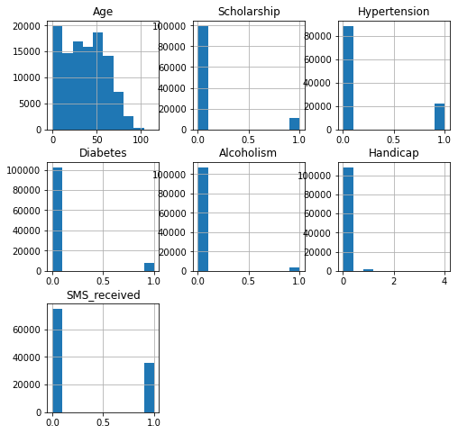

```python
df.hist(figsize = (8,8));
```

It can be implied from the above information that most of the patients are between the ages of 0 to 50. Also, most patients are not enrolled in the Brasilian welfare program since a lot more have no scholarships. Most patients are also not hypertensive, non alcoholics, non diabetic, not handicaped and did not receive any SMS about their appointments.

The questions posed on the about the dataset and exploration of how they can be answered are shown below:

### Q1. Does the gender of a patient determine whether they show up for an appointment?

To answer this, the dataset is first separated based on whether a patient is male or female

```python
df_f = df[df['Gender'] == 'F']
df_f.head()
```

|  | Gender | Age | Neighbourhood | Scholarship | Hypertension | Diabetes | Alcoholism | Handicap | SMS_received | No_Show |
| --- | --- | --- | --- | --- | --- | --- | --- | --- | --- | --- |
| 0 | F | 62 | JARDIM DA PENHA | 0 | 1 | 0 | 0 | 0 | 0 | No |
| 2 | F | 62 | MATA DA PRAIA | 0 | 0 | 0 | 0 | 0 | 0 | No |
| 3 | F | 8 | PONTAL DE CAMBURI | 0 | 0 | 0 | 0 | 0 | 0 | No |
| 4 | F | 56 | JARDIM DA PENHA | 0 | 1 | 1 | 0 | 0 | 0 | No |
| 5 | F | 76 | REPÚBLICA | 0 | 1 | 0 | 0 | 0 | 0 | No |

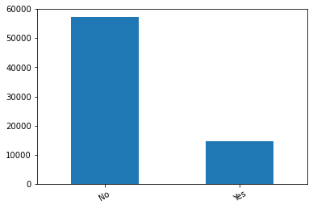

```python
df_f['No_Show'].value_counts().plot(kind='bar', rot=30);
```

The bar chart shows the number of females who showed up or did not showed up for their appointments. Most of the female patients showed up for their appointments as compared to those that did not.

```python
df_m = df[df['Gender'] == 'M']
df_m.head()
```

|  | Gender | Age | Neighbourhood | Scholarship | Hypertension | Diabetes | Alcoholism | Handicap | SMS_received | No_Show |
| --- | --- | --- | --- | --- | --- | --- | --- | --- | --- | --- |
| 1 | M | 56 | JARDIM DA PENHA | 0 | 0 | 0 | 0 | 0 | 0 | No |
| 11 | M | 29 | NOVA PALESTINA | 0 | 0 | 0 | 0 | 0 | 1 | Yes |
| 13 | M | 28 | NOVA PALESTINA | 0 | 0 | 0 | 0 | 0 | 0 | No |
| 16 | M | 50 | NOVA PALESTINA | 0 | 0 | 0 | 0 | 0 | 0 | No |
| 22 | M | 13 | CONQUISTA | 0 | 0 | 0 | 0 | 0 | 1 | Yes |

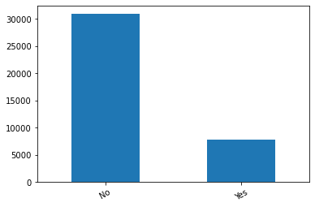

```python
df_m['No_Show'].value_counts().plot(kind='bar', rot=30);
```

The bar chart above shows the number of males who showed up or did not showed up for their appointments. Most of the male patients showed up for their appointments as compared to those that did not.

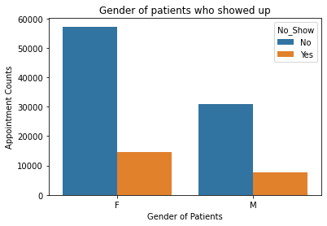

```python
def barplot(value, name, title, xlabel, ylabel):
    name = sns.countplot(x = value, hue = 'No_Show', data = df)
    name.set_title(title)
    plt.xlabel(xlabel)
    plt.ylabel(ylabel)
    plt.show()

barplot('Gender', Sex, 'Gender of patients who showed up', 'Gender of Patients', 'Appointment Counts')
```

The above plot shows the counts of each gender and whether or not they showed up for their appointment. It can be observed that while most male and female patients made it for their appointments, there are more females as compared to males hence the reason why the female bars are longer. However generally, most of the male and female patients showed up for their appointments. The code used for the above plot was gotten from https://datagy.io/seaborn-barplot/ and a function was defined for it so it can be used subsequently in the analysis.

### Q2. Does the age of a patient determine whether they show up for an appointment?

A general summary of age data can be explored. It has earlier been established that the minimum age is 0 and the maximum age is 115. The mean age can also be checked.

```python
age_mean = df['Age'].mean()
age_mean
```

```
37.089218826339504
```

The mean age is approximately 37 years.

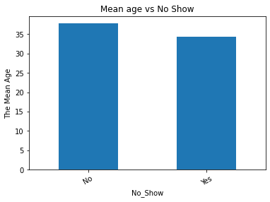

```python
df.groupby('No_Show')['Age'].mean().plot(kind='bar', rot=30)
plt.ylabel('The Mean Age');
plt.title("Mean age vs No Show");
```

```python
df_n = df[df['No_Show'] == 'No']
df_n.head()
```

|  | Gender | Age | Neighbourhood | Scholarship | Hypertension | Diabetes | Alcoholism | Handicap | SMS_received | No_Show |
| --- | --- | --- | --- | --- | --- | --- | --- | --- | --- | --- |
| 0 | F | 62 | JARDIM DA PENHA | 0 | 1 | 0 | 0 | 0 | 0 | No |
| 1 | M | 56 | JARDIM DA PENHA | 0 | 0 | 0 | 0 | 0 | 0 | No |
| 2 | F | 62 | MATA DA PRAIA | 0 | 0 | 0 | 0 | 0 | 0 | No |
| 3 | F | 8 | PONTAL DE CAMBURI | 0 | 0 | 0 | 0 | 0 | 0 | No |
| 4 | F | 56 | JARDIM DA PENHA | 0 | 1 | 1 | 0 | 0 | 0 | No |

```python
df_y = df[df['No_Show'] == 'Yes']
df_y.head()
```

|  | Gender | Age | Neighbourhood | Scholarship | Hypertension | Diabetes | Alcoholism | Handicap | SMS_received | No_Show |
| --- | --- | --- | --- | --- | --- | --- | --- | --- | --- | --- |
| 6 | F | 23 | GOIABEIRAS | 0 | 0 | 0 | 0 | 0 | 0 | Yes |
| 7 | F | 39 | GOIABEIRAS | 0 | 0 | 0 | 0 | 0 | 0 | Yes |
| 11 | M | 29 | NOVA PALESTINA | 0 | 0 | 0 | 0 | 0 | 1 | Yes |
| 17 | F | 40 | CONQUISTA | 1 | 0 | 0 | 0 | 0 | 0 | Yes |
| 20 | F | 30 | NOVA PALESTINA | 0 | 0 | 0 | 0 | 0 | 0 | Yes |

Two dataframes are created to contain all patients who showed up for their appointments and those that did not. the above dataframes can then be used to plot graphs showing the relationship between the ages and showing up for appointments.

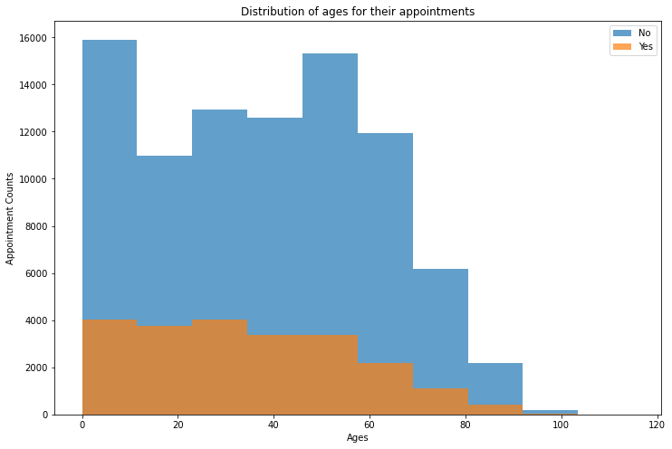

```python
def plot(value1, value2, title, xlabel, ylabel):
    fig, ax = plt.subplots(figsize=(12,8))
    ax.hist(value1, alpha=0.7, label='No')
    ax.hist(value2, alpha=0.7, label='Yes')
    ax.set_title(title)
    ax.set_xlabel(xlabel)
    ax.set_ylabel(ylabel)
    ax.legend(loc='upper right')
    plt.show()

plot(df_n['Age'], df_y['Age'], 'Distribution of ages for their appointments', 'Ages', 'Appointment Counts')
```

### Q3. Does a patient showing up for an appointment depend on receiving an SMS?

The data can be explored to find out the amount of people who showed up for the appointment after receiving an SMS using a bar chart and a seaborn count plot.

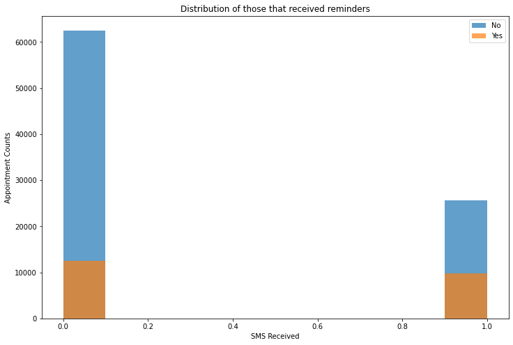

```python
plot(df_n['SMS_received'], df_y['SMS_received'], 'Distribution of those that received reminders', 'SMS Received', 'Appointment Counts')
```

It can be observed that a lot of patients did not receive reminders for their appointments and for those that received reminders, about 25% of them did not show up for the appointment.

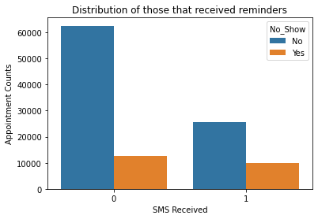

```python
barplot('SMS_received', SMS, 'Distribution of those that received reminders', 'SMS Received', 'Appointment Counts')
```

This graph is similar to the bar chart. However it separates those who did not show up for their appoiuntments from the bar chart where it is embedded in the bar of those the showed up. Also, it can be inferred that about 25000 patients showed up after receiving their reminders.

### Q4. Does a patient having a scholarship determine whether they show up for an appointment?

Like in the earlier exploration, a bar chart and seaborn countplot can be used to explore this question.

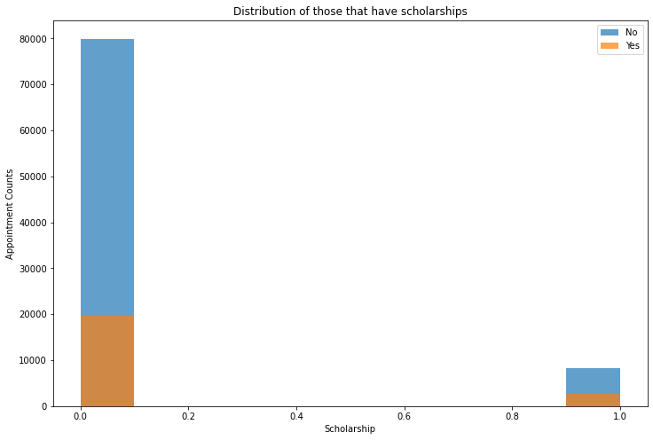

```python
plot(df_n['Scholarship'], df_y['Scholarship'], 'Distribution of those that have scholarships', 'Scholarship', 'Appointment Counts')
```

It can be observed that a lot of patients did not have scholarships, that is, they were not enrolled in the Brazil welfare program. Of those that were enrolled, only a few missed their appointments.

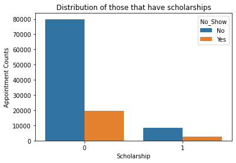

```python
barplot('Scholarship', Ship, 'Distribution of those that have scholarships', 'Scholarship', 'Appointment Counts')
```

From this plot it can be inferred that about 20-25% of patients who had scholarships still missed their appointments. But a lot more patients had no scholarships and still made it for their appointments.

## Conclusions

### Findings

[output not shown]

### Limitations

```
1. There was no way to find out if reminders were sent to everyone or only those who did not show up and how soon they were sent.
1. The data could have been explored more using the health conditions of the patients.
2. An entire row was dropped due to the negative age of a patient which might have been keyed in wrongly.
```